# Disinformation in Twitter -- The Trash do Structure in Network？

## 1. Background

The disinformation disrespects a lot of issues in twitter, with incredible amount that we may confront everytime when opening the APP. We hate the frauds all the time, but meanwhile it is not hard to guess they should have a strategy that arouse most people in social network and spread in a highly efficient way.

To figure out how, to get back control, to return our healthy network, the essay analyzes the intuitives that this disinformation comes out in Twitter, and carries difference analysis among the network.

In the end, the essay returns gives the conclusion and related further potential research.

```python
import pandas as pd
import numpy as np
import csv

import pickle
import ast
from collections import Counter

import seaborn as sns
import matplotlib.pyplot as plt
from adjustText import adjust_text

import imageio
from wordcloud import WordCloud, ImageColorGenerator

# network analysis
import networkx as nx
from networkx.algorithms import community

# text analysis
import string
from gensim.parsing.preprocessing import STOPWORDS
from nltk.tag import pos_tag
from nltk.tokenize import word_tokenize
from nltk.stem import WordNetLemmatizer
from gensim.models import Word2Vec
from sklearn.decomposition import PCA

import warnings
warnings.filterwarnings("ignore")
```

```python
file_name = "russia_201901_1_tweets_csv_hashed.csv"

def boldprint(text):
    """bold the text before printing"""
    return '\033[1m' + text + '\033[0m'

WNL = WordNetLemmatizer()
def preprocess(text):
    """process the text by cleanning, removing and lemmatizing"""
    result = []
    try:
        if text != "":
            if not (text[:4] == "http" and len(text.split()) == 1):
                text = text.translate({ord(c): None for c in string.punctuation+"…’•—“”‘’"}).lower()
                for word, tag in pos_tag(word_tokenize(text)):
                    if word not in STOPWORDS and not word.isdigit() and word != "rt":
                        if tag.startswith("NN"):
                            word = WNL.lemmatize(word, pos='n')
                        elif tag.startswith('VB'):
                            word = WNL.lemmatize(word, pos='v')
                        elif tag.startswith('JJ'):
                            word = WNL.lemmatize(word, pos='a')
                        result.append(word)
    except Exception:
        print(Exception)
        print(text)
        return(result)
    return result
```

## 2. Data

The essay uses data from *<Russia (January 2019) - 416 accounts>* since Russia is quite active in this kind of issue and its evident expeience may be easy to testify, which may result to supervised modelling in the future.

It is a file with 765246 documents and 30 attributes. They are tweets that are connected to state-backed information operations by Twitter, among which most are retweets, along with retweeted user and corresponding statistics.

Hereby the essay utilizes *userid* and *retweet__userid* to build the network and *tweet__text* to build work2vec modelling, and other attributes are also included to make other regular pattern detection.

```python
# get column and modify types
dict_dtype = {}
with open(file_name, "r") as f:
    reader = csv.reader(f)
    for column in reader:
        for attribute in column:
            if "id" in attribute:
                dict_dtype[attribute] = str
        break
# read data
df_disinfo = pd.read_csv(file_name, dtype=dict_dtype,
                         parse_dates=['tweet_time'], low_memory=False)
# initial print
for i, j in dict(df_disinfo.iloc[4]).items():
    print(boldprint(i), j)

users = list(df_disinfo.userid)
```

```
tweetid 630988235649347584
userid 2980186012
user_display_name Infidel II 🕋💣🕋💩
user_screen_name CathyTo47590555
user_reported_location USA  #IslamIsTheProbem #WakeUp
user_profile_description I believe that OUR COUNTRY needs to BAN ISLAM and #DeportALLMOSLEMS! Islam is pure evil! STANDUP, FIGHTBACK, SPEAKUP TAKE OUR COUNTRY BACK .. #INFIDELFORLIFE
user_profile_url nan
follower_count 8685
following_count 1451
account_creation_date 2015-01-15
account_language en
tweet_text RT @HuffPostPol: Rick Perry's campaign staff is reportedly not getting paid http://t.co/cCLMT7fWPk http://t.co/xsNPYqftRN
tweet_time 2015-08-11 06:24:00
tweet_client_name Twitter for iPhone
in_reply_to_tweetid nan
in_reply_to_userid nan
quoted_tweet_tweetid nan
is_retweet True
retweet_userid 15458694
retweet_tweetid 630947019092303872
latitude absent
longitude absent
quote_count 0.0
reply_count 0.0
like_count 0.0
retweet_count 0.0
hashtags []
urls [http://huff.to/1MlMpgm]
user_mentions [HuffPostPol]
poll_choices nan
```

```python
## This part is commented because it will cost a long time.

# total_length = len(df_disinfo)
# all_text = []
# for index, text in enumerate(df_disinfo["tweet_text"]):
#     text = preprocess(text)
#     if (index+1)%1000 == 0:
#         print("{:.2%} Done.".format((index+1)/total_length), end='\r')
#     if index + 1 == total_length:
#         print("100% Done.")
#     all_text.append(text)

# with open("text_processed", "wb") as file:
#     pickle.dump([all_text, df_disinfo["userid"].tolist()], file)

with open("text_processed", "rb") as file:
    all_text, _ = pickle.load(file)
# print("Model saved.")
```

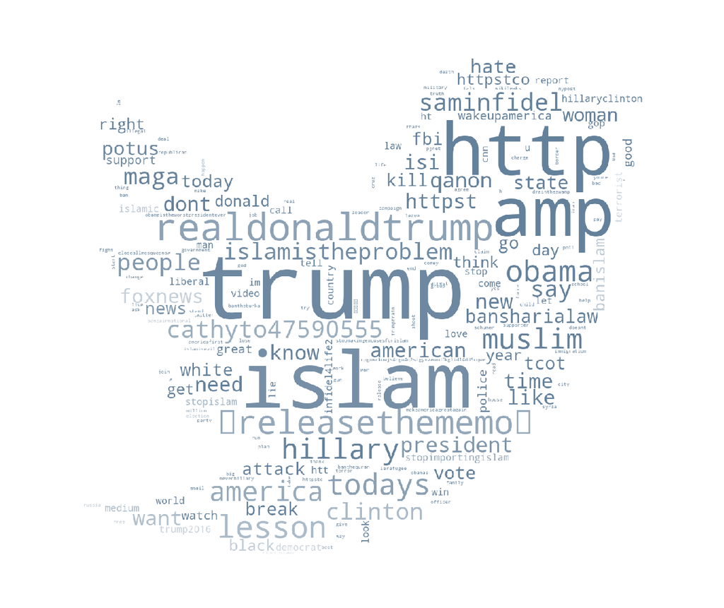

```python
def draw_cloud(word_freq):
    """Generate word cloud"""
    fig, ax = plt.subplots(figsize=(20, 20))
    mask_img = imageio.imread("twitter.png") # set background photo
    image_colors = ImageColorGenerator(mask_img)
    cloud = WordCloud(collocations=False,
                      max_words=200,
                      background_color='white',
                      mask=mask_img,
                      ).generate_from_frequencies(word_freq)
    plt.imshow(cloud.recolor(color_func=image_colors))
    plt.axis('off')
    plt.show()

draw_cloud(pd.Series(dict(Counter([i for item in all_text for i in item]).most_common())))
```

> The bird is covered by Trump, Islam et al..

## 2. Networking

#### 2.1 Brief Introduction

Twitter is a social network, so disinformation in it also spreads by and as network. The data in *retweet__userid* not only gives the state-backed operated users but also the regular (or not yet identified) ones. To have deeper understanding, I carried some visualizations below.

```python
# choose the ids to connect network
df_edges = df_disinfo[["userid", "retweet_userid"]].dropna().rename(columns={"userid": "target", "retweet_userid":"source"})
df_edges = df_edges.groupby(["target", "source"]).size().reset_index().rename(columns={0: "weight"})
G = nx.from_pandas_edgelist(df_edges, edge_attr=True)
G.name = "Disinformation"

nx.info(G).split("\n")
```

```
['Name: Disinformation',
 'Type: Graph',
 'Number of nodes: 79151',
 'Number of edges: 103965',
 'Average degree:   2.6270']
```

#### 2.2 Draw the CDF plot by its degree

The essay Log-transform the degrees to make it easy to see.

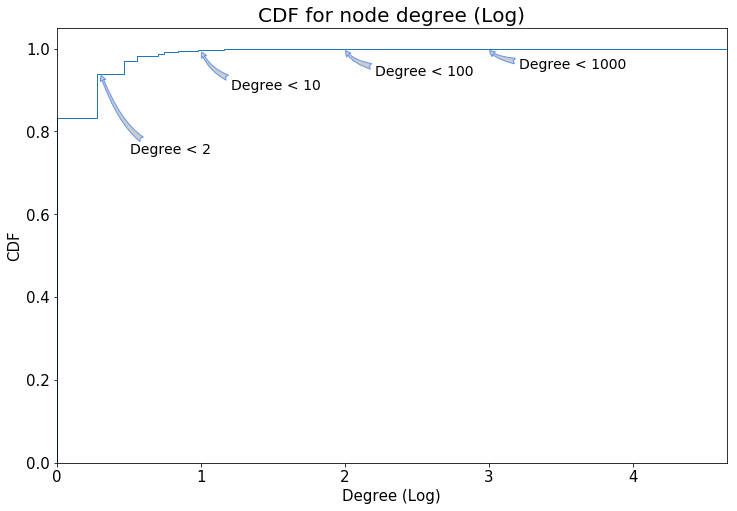

```python
degrees = np.log10(sorted([d for n, d in G.degree()], reverse=True)) # sort the degree
fig, ax = plt.subplots(figsize=(12, 8))
n1, _bins, _patches = ax.hist(degrees, bins=100, density=1, histtype='step', cumulative = 1)
ax.set_xlim(min(degrees), max(degrees))
ax.set_title('CDF for node degree (Log)', fontsize=20)
ax.set_xlabel("Degree (Log)", fontsize=15)
ax.set_ylabel("CDF", fontsize=15)
ax.tick_params(labelsize=15)

# add the annotates to show where the point is
for index, degree in enumerate([2, 10, 100, 1000]):
    x = np.log10(degree)
    y = n1[np.argmin([abs(bin_value-x) for bin_value in _bins])]
    ax.annotate('Degree < %d'%degree, xy=(x, y), xycoords='data',
                xytext=(30,-80/(index+1)), textcoords='offset points', fontsize=14,
                arrowprops=dict(arrowstyle='fancy',fc='0.8', color='#6495ed',
                                connectionstyle="angle3,angleA=0,angleB=-70"));
```

> Around 80% of the nodes in the network only have 1 degree that means this node has only one text that is retweeted or retweeting. Almost all nodes have less than 10 degrees. While there are only a few nodoes hold more than 100 degrees, this phenomenon agrees with the long-tail theory in social network.

#### 2.3 Connected Components Detection

The essay finds the connected components in the whole network. It turns out that only 1 component has more than 10 nodes that is 79026 while others are all below 10 and most are 2. So the essay hereby only concerns the largest one, due to lack of knowledge from other components.

```python
components = list(nx.connected_components(G))
components_lengths = [str(len(i)) for i in components]
print("The number of nodes in each component is %s."%(", ".join(components_lengths)))
print("The number of components larger than 10 nodes is %d."%len([i for i in components_lengths if int(i)>10]))

SG1 = nx.OrderedGraph()
SG1.add_nodes_from(sorted(list(components[0])))
SG1.add_edges_from((u, v) for (u, v) in G.edges() if u in SG1 if v in SG1)

nodes = [i for i, j in SG1.degree if j>10]
SG2 = nx.OrderedGraph()
SG2.add_nodes_from(nodes)
SG2.add_edges_from((u, v) for (u, v) in SG1.edges() if u in SG2 if v in SG2)
print("The number of high degree nodes is %d."%len(nodes))
```

```
The number of nodes in each component is 79026, 5, 4, 3, 2, 2, 2, 2, 3, 2, 6, 2, 2, 2, 2, 3, 3, 9, 2, 2, 2, 2, 2, 2, 3, 2, 2, 2, 3, 2, 3, 2, 3, 6, 6, 3, 7, 2, 2, 3, 2, 2, 4.
The number of components larger than 10 nodes is 1.
The number of high degree nodes is 302.
```

#### 2.4 Network Visualization

The essay hereby builds the network, shows only nodes with more than 4 degrees, and labels the operated users by `+`, and conducts community detection to divide it into bisections (two parts).

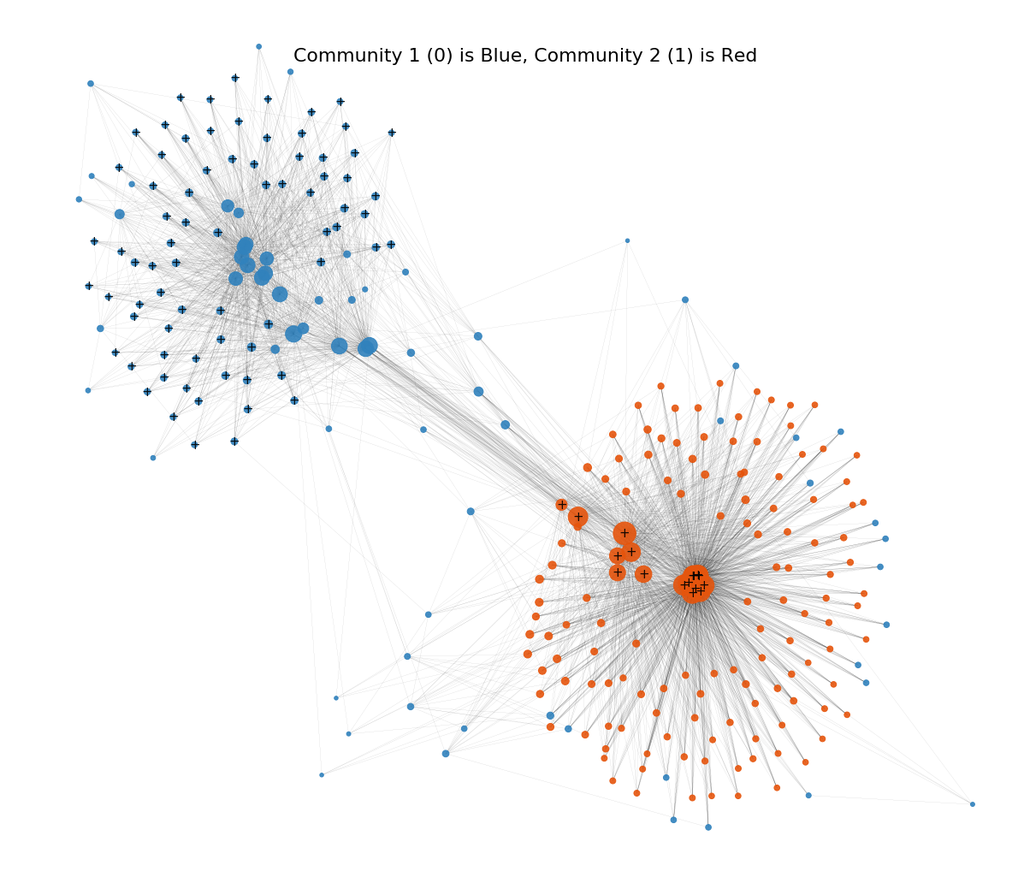

```python
nodelist = []
node_size = []
for i, j in SG2.degree:
    if j > 4: # larger degree to show graph well
        nodelist.append(i)
        node_size.append(j*4)

SG = nx.OrderedGraph()
SG.add_nodes_from(nodelist)
SG.add_edges_from((u, v) for (u, v) in SG2.edges() if u in SG if v in SG)

# community detection
communities = community.kernighan_lin_bisection(SG, seed=1)
colors = plt.get_cmap("tab20c")(np.arange(len(communities))*4)

# get the two communities respectively
H1 = SG.subgraph(communities[0])
H2 = SG.subgraph(communities[1])
labeled_nodes = [i[0] for i in sorted(H1.degree, key=lambda x: x[1], reverse=True)[:100]] + \
                [i[0] for i in sorted(H2.degree, key=lambda x: x[1], reverse=True)[:100]]

plt.figure(figsize=(16, 14))
pos = nx.spring_layout(SG, seed=1)
nx.draw(SG, pos = pos,
        nodelist = nodelist,
        node_size = node_size,
        node_color = [colors[0] if i in communities[0] else colors[1] for i in nodelist],
        labels = {i: "+" for i in labeled_nodes if i in users},
        width=0.05, alpha=0.9, font_size=15)
plt.title("Community 1 (0) is Blue, Community 2 (1) is Red", fontsize=22, y=0.93)
plt.show()
```

> The network is divided into two communities, i.e. Community 1 (Blue) and Community 2 (Red), represented by 0/1 in the codes.

> Interestingly, the Blue community's operated users are not the ones with the largest influence, while the strongest users in the Red community are all operated users.

> If a disinformation organization wants to spread their news, they cannot make all nodes in one community, which leads to no news expanding outside. It is better if they set some strong nodes in the network, but the fake supporters are in other networks, say strong for arousing, ordinary for attracting. From the graph, we can see that these operated users (the trash) are well structured that some act as the **storm centers** (Red Community) that organize their innocent fans, others act as the **disguised civilians**, further affecting their pursuit objects and corresponding community.

#### 2.5 Proportion Visualization

The essay hereby further analyzes the above network by showing its proportions.

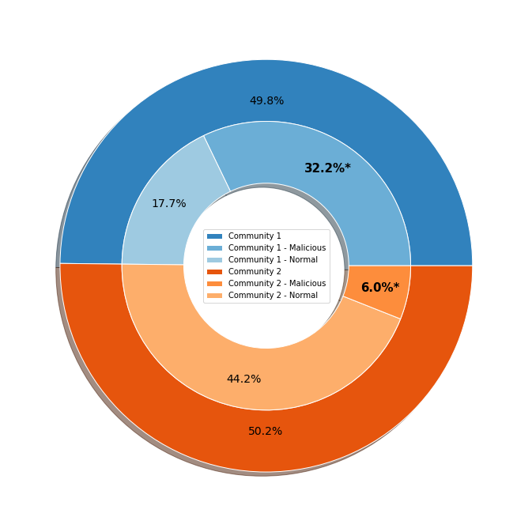

```python
fig, ax = plt.subplots(figsize=(12, 12)) # draw the two nested pie plots

community1_malicious = len([i for i in communities[0] if i in users])
community2_malicious = len([i for i in communities[1] if i in users])

size = 0.3
vals = np.array([[community1_malicious, len(communities[0]) - community1_malicious],
                 [len(communities[1]) - community2_malicious, community2_malicious]])

_, texts1, percs1 = ax.pie(vals.sum(axis=1), radius=1, colors=plt.get_cmap("tab20c")(np.arange(2)*4),
       wedgeprops=dict(width=size, edgecolor='w'), autopct='%1.1f%%',shadow=True,
       pctdistance=0.8, labels=["Community 1", "Community 2"])

_, texts2, percs2 = ax.pie(vals.flatten(), radius=1-size, colors=plt.get_cmap("tab20c")(np.array([1, 2, 6, 5])),
       wedgeprops=dict(width=size, edgecolor='w'), autopct='%1.1f%%', shadow=True,
       pctdistance=0.8, labels=["Community 1 - Malicious", "Community 1 - Normal", "Community 2 - Normal", "Community 2 - Malicious"])

for t in texts1: # remove the labels in the graph
    t.remove()
for t in texts2:
    t.remove()

for p in percs1: # modify the fonts
    p.set_fontsize(14)
for index, p in enumerate(percs2):
    p.set_fontsize(14)
    if index in [0, 3]:
        p.set_text(p.get_text() + "*")
        p.set_fontweight(weight="bold")
        p.set_fontsize(15)

handles, labels = ax.get_legend_handles_labels() # make the labels beautiful
handles = [handles[i] for i in [0, 2, 3, 1, 5, 4]]
labels = [labels[i] for i in [0, 2, 3, 1, 5, 4]]

ax.legend(handles,labels, prop={"size": 10}, loc=10)
plt.show();
```

> Most users is community 1 (Blue) are operated; however, this most part does not hold the strongest influence. Whereas community 2 (Red) is on the right contrary and the greatest useres are all malicious, which agrees with network visualization.

#### 2.6 Pattern Explore

The essay also compare this two kind of operated users. By looking at graphs below, we can clearly see the activities difference between them.

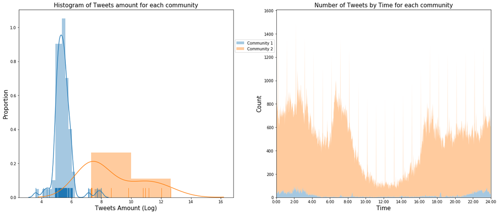

```python
df_time1 = df_disinfo.loc[df_disinfo["userid"].isin(communities[0]), ["userid","tweet_time"]]
df_time2 = df_disinfo.loc[df_disinfo["userid"].isin(communities[1]), ["userid","tweet_time"]]

# get the tweets aomunt
lengths = [np.log(list(df_time1.groupby("userid").size())),
           np.log(list(df_time2.groupby("userid").size()))]

f, axes = plt.subplots(ncols=2, figsize=[22, 9])

ax = axes[0]
sns.distplot(lengths[0], kde=True, hist=True, rug=True, ax=ax)
sns.distplot(lengths[1], kde=True, hist=True, rug=True, ax=ax)
ax.set_ylabel("Proportion", fontsize=15)
ax.set_xlabel("Tweets Amount (Log)", fontsize=15)
ax.set_title("Histogram of Tweets amount for each community", fontsize=15)

# get the times histogram
times = [df_time1["tweet_time"].dt.minute + df_time1["tweet_time"].dt.hour*60,
         df_time2["tweet_time"].dt.minute + df_time2["tweet_time"].dt.hour*60]
n1, _bins = np.histogram(times[0], bins=range(24*60+1))
n2, _bins = np.histogram(times[1], bins=range(24*60+1))

ax = axes[1]
ax.stackplot(range(24*60), [n1, n2], edgecolor='none', alpha = 0.4)
ax.set_xticks(60*np.arange(0, 26, 2)) # only draw even hours
ax.set_xticklabels([str(i) + ":00" for i in range(0, 26, 2)])
ax.set_xlim([0, 24*60])
ax.set_xlabel('Time', fontsize=15)
ax.set_ylabel('Count', fontsize=15)
ax.set_title("Number of Tweets by Time for each community", fontsize=15)
ax.legend(["Community 1", "Community 2"], bbox_to_anchor=(0, 0.85));
```

> From the left graph, most operated users in Community 1 (Blue) have less tweets than that in Community 2 (Red). And the users in Community 2 (Red) are more diversed and some pushed a really large amount of tweets. It may be illustrated by the **storm centers** should write more to arouse others while **disguised civilians** only need to response a lot less.

> From the right graph, Community 2 (Red) operated tweeets are quite extensive, which is far larger than Community 1 (Blue). This may be due to the same reason above. The weird pattern may explain how the disinformation company operates.

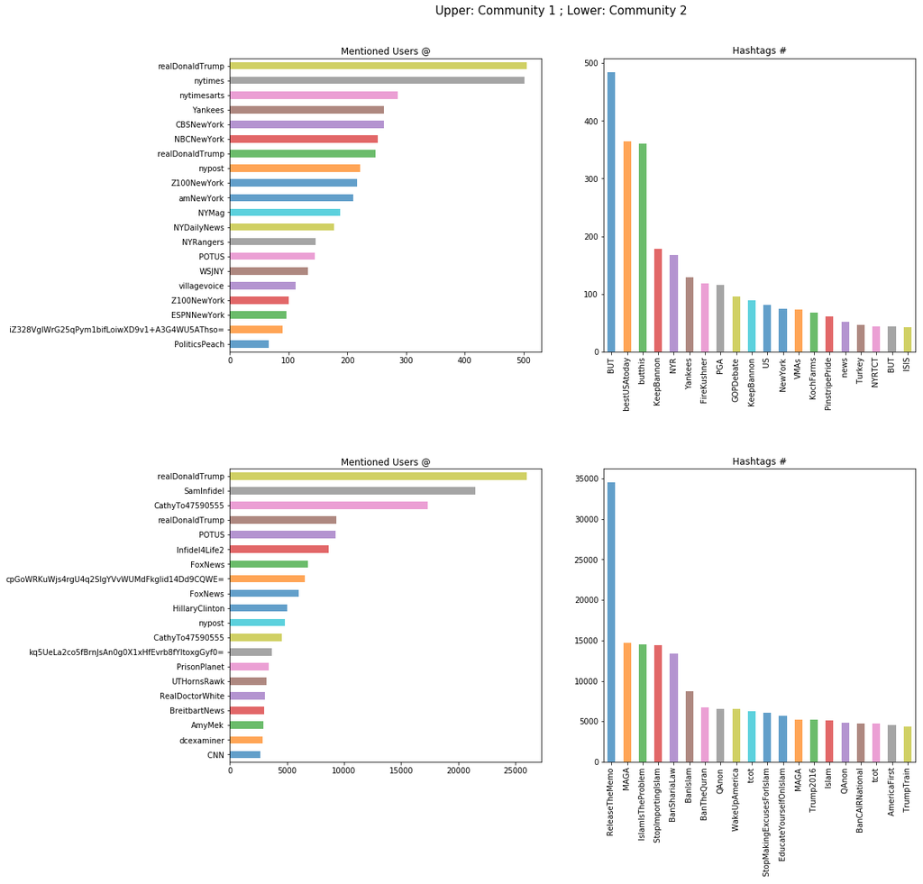

```python
fig, axes = plt.subplots(ncols=2, nrows=2, figsize=(16, 16))

hashtag_count = []
mention_count = []
for index, community_temp in enumerate(communities):
    hashtags = []
    user_mentions = []
    df_symbols = df_disinfo.loc[df_disinfo["userid"].isin(community_temp), ["hashtags", "user_mentions"]]
    for _, df in df_symbols.iterrows():
        if type(df["hashtags"]) is str and type(df["user_mentions"]) is str:
            hashtags.extend(df["hashtags"].replace("[","").replace("]","").split(","))
            user_mentions.extend(df["user_mentions"].replace("[","").replace("]","").split(","))
    # not show the ""
    hashtag_count.append(pd.Series(dict(Counter(hashtags).most_common()))[1:])
    mention_count.append(pd.Series(dict(Counter(user_mentions).most_common()))[1:])
    # show only 20 of them
    hashtag_count[index].head(20).plot(kind='bar', alpha=0.7, ax=axes[index][1], title="Hashtags #") # remove #brexit which is too many
    mention_count[index].head(20)[::-1].plot(kind='barh', alpha=0.7, ax=axes[index][0], title="Mentioned Users @") # horizontal bar plot

fig.subplots_adjust(wspace=0.2, top=0.92, hspace=0.4)
fig.suptitle("Upper: Community 1 ; Lower: Community 2", fontsize=15);
```

> Upper section and Lower section are quite different. Community 1 focuses more on *Donald Trump*, while Community 2 takes emphasis on *Islam*.

> Community 1 mentions most news press, like NY, CBS and NBC, except @realDonaldTrump. And their hashtags are presented highly weird and back-operated with a fixed pattern, i.e. #BUT and #BestUSAtoday, with a exception, #KeepBannon, who is the right wing helper of Trump. Likely, Community 1 is just the fake supporters group for the right wing, but produces trash information to pretend to be the true people, in which the non-sense @ and # can be detected for filtering.

> Community 2, on the other hand, @Saminfidel, @Infidel4Life2 are two anti-Islam accounts that have been cancelled. #IslamTheProblem and #StopImportingIslam are clear by its name. @realDonaldTrump, @POTUS (President of the United States), and #ReleaseTheMemo (a rallying cry for the right and Trump supporters), #MAGA (Make America Great Again) #QAnon (far-right conspiracy theory by Trump supporter) are clearly targeted on the right-wing, especially Donald Trump and rally behind them. As the influential nodes, the operated users in this community spread these emotional news to rally for the right-wing and Trump.

> In conclusion, Community 1 is mainly operated by these fake right-wing supporters to pretend to be a big crowd and attract more, while Community 2 is used to propose Trump and Islam issue to the innocent public.

## 3. Word2Vec

#### 3.1 Brief Introduction

Twitter also gives quite a few tweets text data, in which the essay analyzes the differences of the tweets of the two communities. First the essay acquires the two small model by two communities text data, respectively. Then the essay conducts the big word2vec model by the whole data.

```python
# model = Word2Vec(all_text)
# print("Model established.")
# model.save('twitter_word2vec_model.bin')
model = Word2Vec.load('twitter_word2vec_model.bin')
```

#### 3.2 Seperated Model

Here the essay builds the two different model by different text input to see how the two communities recognize differing words.

```python
# model1 = Word2Vec(np.array(all_text)[np.array([i in communities[0] for i in df_disinfo["userid"].tolist()])])
# model2 = Word2Vec(np.array(all_text)[np.array([i in communities[1] for i in df_disinfo["userid"].tolist()])])
# model1.save('twitter_word2vec_model1.bin')
# model2.save('twitter_word2vec_model2.bin')

model1 = Word2Vec.load('twitter_word2vec_model1.bin')
model2 = Word2Vec.load('twitter_word2vec_model2.bin')

print(boldprint("Trump"))
print(boldprint("Community 1:"), ", ".join([i[0] for i in model1.wv.most_similar("trump", topn=20)]))
print(boldprint("Community 2:"), ", ".join([i[0] for i in model2.wv.most_similar("trump", topn=20)]))
print(boldprint("\nIslam"))
print(boldprint("Community 1:"), ", ".join([i[0] for i in model1.wv.most_similar("islam", topn=20)]))
print(boldprint("Community 2:"), ", ".join([i[0] for i in model2.wv.most_similar("islam", topn=20)]))
```

```
Trump
Community 1: jeb, donald, transcript, megyn, bush, birthright, kelly, immigration, moderator, uncomfortable, republican, fox, constant, sinking, conservative, wing, baby, ail, charity, owe
Community 2: trumps, realdonaldtrumps, t, realdonaldtrump, opponent, instead, republican, he, candidate, push, donaldtrumpinfo, pr, have, amp, gop, rnc, romney, promise, establishment, decision

Islam
Community 1: dystopian, situation, usaneedstrump, glass, warns, thought, butt, scene, plant, hippie, reject, allas, bitcoin, kik, nostalgically, alert, htt, modernism, anastacilia, affiliate
Community 2: islams, isla, subjugate, lesson, kafir, islamism, jihadism, m103, ideology, manchesterbombing, quran, stopimportingislam🕌☠️💩🕋, islamophobes, koran, nonbeliever, barbaric, nonmuslims, ba, medieval, mu
```

> Here result evidently shows the differences of how two communities regard different words, both related or not related to the community targets.

> Community 1, as Trump' fake supporters, shows focus on the political issues that has similar quality with Community 2 about word Trump. On the other hand, Community 2 presents its extreme attitudes towards Islam, while community 1 is even normal.

> In conclusion, the two communities show different target as showed before, and this Word2Vec model is also possible for aim detection in the future.

#### 3.3 Whole Model

The essay hereby aggregate all text data to conduct a big Word2Vec model. In below graph, the words related to *@realDonaldTrump* and *@Saminfidel* who is an anti-Islam user, are drawed, as well as *#trump* and _#islam, which are positioned by PCA reflecting to two-dimension.

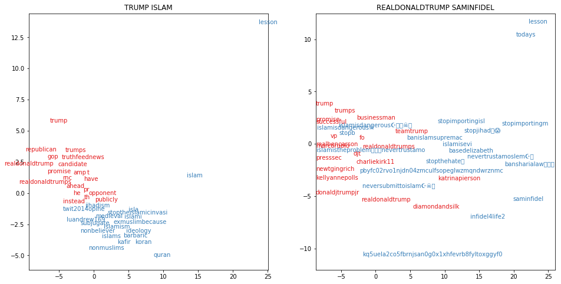

```python
def plot_pca(names, model, ax):
    show_count = 20
    words = []
    for name in names:
        words.append(name)
        words.extend([i[0] for i in model.wv.most_similar(name, topn=show_count-1)])

    # fit a 2d PCA model to the vectors
    X = model.wv.__getitem__(words)
    pca = PCA(n_components=2)
    result = pca.fit_transform(X)
    ax.scatter(result[:, 0], result[:, 1], facecolors='none', edgecolors='none')

    texts = []
    for index, word in enumerate(words):
        color = int(index / show_count)
        texts.append(ax.text(result[index, 0], result[index, 1], word,
                            color=plt.cm.Set1(color), label=color))
    ax.set_title(" ".join(names).upper())
    adjust_text(texts, only_move={'points':'y'})

fig, axes = plt.subplots(ncols=2, nrows=1, figsize=[16, 8])
plot_pca(["trump", "islam"], model, axes[0])
plot_pca(["realdonaldtrump", "saminfidel"], model, axes[1])
```

> Clearly showed, words related to Trump, and words related to Islam are quite different from each other. By this Word2Vec method, the essay believe it is possible to build a word detection model detecting all words related to these malicious words, or alarmed words. Once related words, with good similarity, come out with a big quantity, our data protection system should be activated to carry the cleaning.

## 4. Conclusion

The essay analyzes the network of disinformation and its characteristics, in which two different type of operated users are found and hold different operation pattern.

Significantly, Community 1 **disguised civilians** are fake right-wing or Trump supporters to rally for him, while Communit 2 **storm centers** are trying to voting for Trump and instigating the hate to Islam.

Furthermore, the essay utilizes Word2Vec to find the different knowledge the two communities have towards different issue. One has more information or attitudes towards its target, but behaves more general towards others.

In the future, for Community 1 **disguised civilians**, I believe having a big corresponding corpus and building Word2Vec model with it will help detecting more trash words around the issue. With KPI changing monitor (especially for the evident #BUT), the attack will be prevented more. As for Communit 2 **storm centers**, I think it will be better if we can set alarms on the influential users with more sensitive models, and quickly cutting connections from them to the public.